# ECON 4362 Empirical Project (Final) slides

## Empirical Project: Supply Chain During The Covid-19 Pandemic

```
Clayton Nabors, Abby Inbusch
Professor Ozak
ECON 4362
Economic Growth
Empirical Project
28 November 2022
```

This semester, for our empirical research project, we have decided to cover the topic of supply chain issues and how it affects the economy. We focused on supply chain issues while the surrounding economy is growing at a faster rate than the supply chain can keep up – with emphasis on the recovery of companies after the Covid-19 pandemic. We found this issue to be very current and relevant to economic growth considering how vital supply chain businesses are to the economy. For example, we found that all of the U.S. supply chain factors such as manufacturing, shipping, retail, etc. make up roughly 37% of all jobs [(Delgado, Mills)](https://hbr.org/2018/03/the-supply-chain-economy-and-the-future-of-good-jobs-in-america). Additionally, the rising costs of wood, fuel, labor, and resources have drastically decreased manufacturing in the supply chain process, which results in further economic issues not only for supply chain industries, but for the world.

[figure not shown]

> How big is the U.S. supply chain economy?

#### What is Supply Chain?

First and foremost, what is supply chain? In simple terms, supply chain is the process from start to finish of manufacturing and selling goods. According to author Adam Hayes, supply chain is “a network between a company and its suppliers to produce and distribute a specific product to the financial buyer; it includes different activities, people, entities, information, and resources” [(Hayes)](https://www.investopedia.com/terms/s/supplychain.asp). With that in mind, supply chain begins with a “supplier” who sources and harvests raw materials such as wood, metal, gas/oil, and other raw materials for the suppliers to sell to manufacturers. Next, depending on what is being manufactured and to what extent, the manufacturers either produce final goods or partially completed products. The final goods are distributed to a retailer of some sort and then sold to a consumer. On the other hand, the partially completed products that are used in the production of other products are sold to another manufacturer that finalizes the goods. Once the final product is in the hands of the customer, it is up to them to decide to use it as a consumer good (personal use) or a capital good (business use).

[figure not shown]

```python
from IPython.display import Image
Image(filename = "data/Supplychain_final_rev-6052ed52d6914d828989e686d9c12c9c.jpg")
```

While the process is easy to explain and understand, the physical process is much more complex, timely, and costly. As a consumer, one might never think of how their sofa was made, or how many different manufacturers made the parts of their home appliances that they use daily. The lack of thought is caused by the convenience of purchasing the final product at a retail store or online and not caring about the process. Additionally, this can also lead to a lack of appreciation and a sense of entitlement for anything and everything to be purchased with the click of a button. The “perfected” supply chain process has groomed the modern-day consumer into thinking that all products will be readily available to purchase whether they want them or not. This mindset came to a halt at the end of 2019 and beginning of 2020 due to the lingering pandemic of “Covid-19”.

[figure not shown]

> Supply chain flow chart

#### How Covid-19 Altered the Supply Chain Process

While many companies that play a role in the supply chain process were halted due to CDC guidelines in the wake of the Covid-19 virus, one company that was able to push through was Amazon. The trillion-dollar company has shaped how the economy and general public understand the coordination of logistics, e-commerce operations, and other supply chain factors. And with an amazon prime membership, this has become the new standard of delivery, with a bulk of their products being delivered in less than 24 hours. The company’s speed of delivery has single-handedly altered people's mindsets into thinking that all companies should be able to deliver just as quickly. Also, because Amazon offers same-day shipping, the world has seen how much we rely on the supply chain process especially when deficiencies arose at the height of the pandemic. Unlike thousands of small businesses and even entire industries being destroyed during the pandemic, Amazon's sales increased while others decreased to an eventual halt or shut down. Specifically, Amazon realized a 37.6% spike in revenue in 2020, which was the first increase of that size since 2011 [(Curry)](https://www.businessofapps.com/data/amazon-statistics/).

Although record-breaking sales may not seem to be a negative effect, from a supply chain standpoint, it was a disaster. Author Annie Palmer from CNBC News reports that “even Amazon, with its sprawling end-to-end logistics network spanning warehouses, planes, trucks, and vans, wasn’t able to keep operations steady” [(Palmer)](https://www.cnbc.com/2020/09/29/how-amazon-managed-the-coronavirus-crisis-and-came-out-stronger.html). The surprising amount of sales at the beginning of the pandemic completely overloaded their supply chain operations to such an extent that Amazon had never seen before. And considering the supply chain is Amazon’s “crown jewel”, they were in desperate need of reorganization and more of essentially everything except new orders [(Palmer)](https://www.cnbc.com/2020/09/29/how-amazon-managed-the-coronavirus-crisis-and-came-out-stronger.html).

Although Amazon is a prime example, the economic issues related to supply chain are not limited to e-commerce companies. Thousands of retailers have suffered, along with the truck drivers, trucking companies, manufacturers, warehouses and many other vital components of the supply chain have also had their fair share of the virus that still affects them today. The demand for products that go through the supply chain process is increasing, while thousands of companies cannot keep up due to the lack of supplies, labor, etc. The problem of it all is the impatient customers who have gone back to living their “pre-pandemic” lives while the supply chain is still suffering. If people learned one thing during and/or post-pandemic, it is that the supply chain process is surprisingly fragile and hard to fully restore back to normal. The process as well as struggles in the supply chain are essentially common knowledge nowadays for people dealing with backordered products or shipping delays all while the economy is growing and continually recovering from the pandemic. Although the issues that Amazon faced were not negatively affecting their revenue (sales), there were thousands of companies that were not (and some still not) able to manufacture certain items due to a shortage of specific supplies.

```python
import  pandas as pd
import matplotlib.pyplot as plt
import warnings
warnings.filterwarnings('ignore')
```

## Amazon Revenue

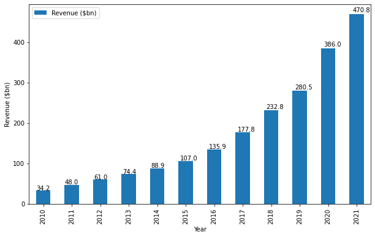

```python
amz_data = pd.read_html("data/Amazon Statistics (2022) - Business of Apps.html", encoding ="utf-8")
amz_rev = amz_data[1]
amz_rev = amz_rev[amz_rev['Year'] >= 2010]
plot = amz_rev.plot(x="Year", y="Revenue ($bn)", kind = "bar", figsize=(10,6), label="Revenue ($bn)")
plot.set_xlabel("Year")
plot.set_ylabel("Revenue ($bn)")
for p in plot.patches:
    plot.annotate(str(p.get_height()), (p.get_x() * 1.01, p.get_height() * 1.01))
plt.show()
```

#### Industry-Specific Hardships During and Post Covid-19

One of the largest industries that was disrupted due to the pandemic is the automobile industry. Due to a computer chip shortage, the automobile industry has seen a radical change unlike anything before. The chip shortage has affected not only manufacturing but also dealers and most importantly, consumers. As the supply chain was fragile, there was a drastic shortage of computer chips. These chips can be used not just for computers, but also for home appliances and automobiles. As the demand for computers drastically rose during quarantine and the majority of the semiconductor chips were used for laptops, the automobile industry took a drastic hit, with “11.3 million unsold vehicles worldwide and more than $200 billion of lost revenues” in 2021 [(Salvage Bid)](https://www.salvagebid.com/blog/the-impact-of-chip-shortage-on-the-auto-industry/). According to a study done by the Economist Intelligence Unit, this industry took the hardest hit during the supply chain disruption from the pandemic [(Lee)](https://www.cnbc.com/2021/08/25/auto-industry-supply-chains-hit-hardest-during-covid-pandemic-survey.html). Domestic auto inventories have dropped by 80.3% since the beginning of the pandemic [(Fred)](https://fred.stlouisfed.org/series/AUINSA).Today, we can see the effects of this with significantly higher prices in both used and new vehicles for sale.

```python
link = "https://www.bls.gov/opub/ted/2022/u-s-manufacturing-output-hours-worked-and-productivity-recover-from-covid-19.htm"
data = pd.read_html(
    link, encoding = 'utf-8')
man_output_df = data[0]
```

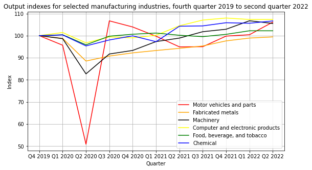

```python
fig, ax = plt.subplots(figsize = (9, 5))
ax.plot(man_output_df["Quarter"], man_output_df["Motor vehicles and parts"],
        color="red", label="Motor vehicles and parts")
ax.plot(man_output_df["Quarter"], man_output_df["Fabricated metals"],
        color="orange", label="Fabricated metals")
ax.plot(man_output_df["Quarter"], man_output_df["Machinery"], color="black", label="Machinery")
ax.plot(man_output_df["Quarter"], man_output_df["Computer and electronic products"],
        color="yellow", label="Computer and electronic products")
ax.plot(man_output_df["Quarter"], man_output_df["Food, beverage, and tobacco"],
        color="green", label="Food, beverage, and tobacco")
ax.plot(man_output_df["Quarter"], man_output_df["Chemical"], color="blue", label="Chemical")
ax.set_xlabel("Quarter")
ax.set_ylabel("Index")
ax.grid()
ax.legend()
plt.title("Output indexes for selected manufacturing industries, fourth quarter 2019 to second quarter 2022")
plt.show()
```

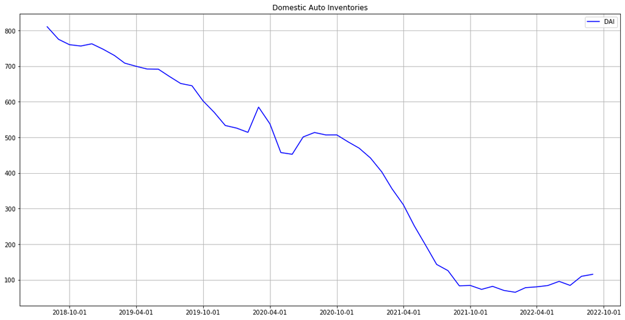

```python
dai_path = "data/DAI.csv"
dai_df = pd.read_csv(dai_path)
dai_df['DATE'] = pd.to_datetime(dai_df['DATE'])
x_ticks = pd.date_range(start = '2018-10-01', end = '2022-12-31', freq='6MS')
fig, ax = plt.subplots(figsize = (18,9))
ax.plot(dai_df['DATE'], dai_df['AUINSA'], color='blue', label= 'DAI')
ax.grid()
ax.legend()
plt.xticks(x_ticks)
plt.title("Domestic Auto Inventories")
plt.show()
```

#### How Covid-19 Affected GDP and Inflation

As Covid-19 heavily affected the supply chain of many goods, there have been many direct economic effects that we can still see today and potentially for years to come. The inflation rate has been rapidly rising since the end of lockdown, concerning consumers, investors, and businesses. The inflation rate has continued to rise past the pre-pandemic levels without an end in sight [(Fred)](https://fred.stlouisfed.org/series/GDP/). Due to the rise in inflation, the Consumer Price Index (CPI) rose by more than 9% between June 2021 and June 2022 [(US Bank)](https://www.usbank.com/investing/financial-perspectives/market-news/supply-chain-issues-contribution-to-inflation.html). This directly affects consumers as the supply of goods is too low to keep up with the strong demand. For example, the CPI for gasoline in the U.S. has risen 24% above the highest peak we’ve had in the last decade [(Fred)](https://fred.stlouisfed.org/series/CUSR0000SETB01#). At the beginning of 2019, gas prices were about 2.25 dollars per gallon . In 2022, gas prices averaged $4.90 per gallon (Hallman). This was in part due to the Russian invasion of Ukraine and the U.S. being an ally to Ukraine. The U.S. relied on imports of oil from Russia, making up about 13% of all US gasoline imports (Elbein). Russia was the third largest contributor to the U.S.’s gasoline imports behind Canada and the Netherlands. Now, without the supply of oil from Russia, we can see prices going up. The price of gasoline directly affects several factors of the supply chain. For example, gasoline is needed for trucks, planes and ships for shipping purposes, but also for the machinery used in the process of manufacturing those goods. And while the vital component needed to make machines run continues to rise in cost, it will continue to negatively impact the supply chain process.

As the Fed has tried to combat these high inflation rates, they have been increasing interest rates. However, consumers and businesses get hit the hardest with high inflation and high interest rates because goods and loans cost more. The idea is to reduce the supply of money in circulation, therefore decreasing inflation. However, people who struggle to afford goods can’t even take out loans to help pay for the goods they need. The Fed’s decision could also send the country into a recession.

With interest rates increasing from 1.59 pre-pandemic to 3.83 today, the stock and bond market are heavily impacted, along with mortgage, personal, student, auto, and business loans [(Fred)](https://fred.stlouisfed.org/series/DFF). As the interest rate increases, it becomes more expensive to do business, impacting the stock market. The bond market is very sensitive to changes with the interest rate. As the interest rate increases, the price of bonds that already exist declines immediately, while new bonds have more expensive interest payments [(O’Connell)](https://www.forbes.com/advisor/investing/fed-raises-interest-rates/).

Despite the gross domestic product’s (GDP) drastic decline at the beginning of the pandemic, the country has been able to combat the drop and continue its growth. At the end of 2019, the GDP for Q4 was 21,706.532 [(Fred)](https://fred.stlouisfed.org/series/GDP/). At the end of lockdown, the GDP for Q2 in 2020 was 19,636.731 [(Fred)](https://fred.stlouisfed.org/series/GDP/). Today, the GDP has rebounded to 25,663.289 [(Fred)](https://fred.stlouisfed.org/series/GDP/).

## CPI

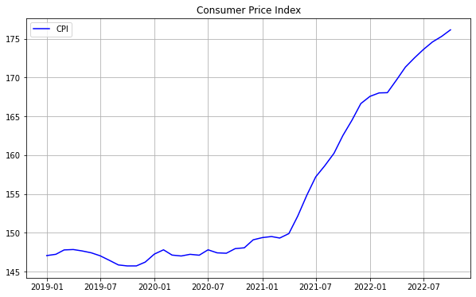

```python
cpi_path = "data/CUUR0000SETA01.csv"
cpi_df = pd.read_csv(cpi_path)
cpi_df['DATE'] = pd.to_datetime(cpi_df['DATE'])
fig, ax = plt.subplots(figsize = (10,6))
ax.plot(cpi_df['DATE'], cpi_df['CUUR0000SETA01'], color='blue', label= 'CPI')
ax.grid()
ax.legend()
plt.title("Consumer Price Index")
plt.show()
```

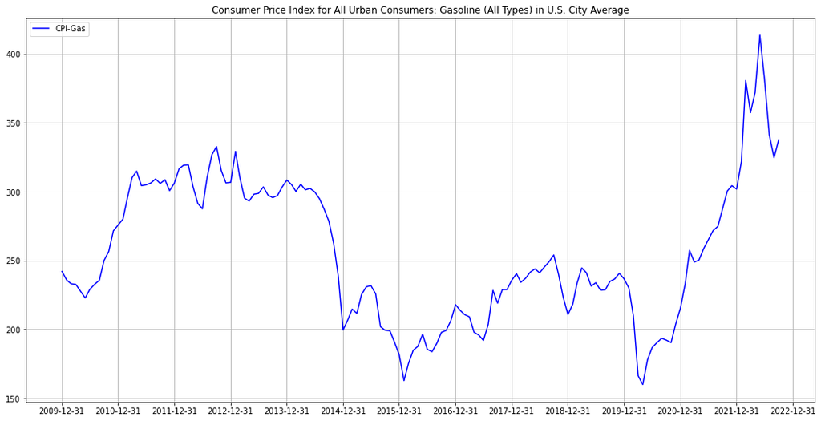

```python
cpi_gas_path = "data/Gasoline CPI.csv"
cpi_gas_df = pd.read_csv(cpi_gas_path)
cpi_gas_df['DATE'] = pd.to_datetime(cpi_gas_df['DATE'])
cpi_gas_df = cpi_gas_df[cpi_gas_df['DATE'] >= '2010-01-01']
x_ticks = pd.date_range(start = '2009-12-31', end = '2022-12-31', freq='1Y')
fig, ax = plt.subplots(figsize = (18,9))
ax.plot(cpi_gas_df['DATE'], cpi_gas_df['CUSR0000SETB01'], color='blue', label= 'CPI-Gas')
ax.grid()
ax.legend()
plt.xticks(x_ticks)
plt.title("Consumer Price Index for All Urban Consumers: Gasoline (All Types) in U.S. City Average")
plt.show()
```

## GDP

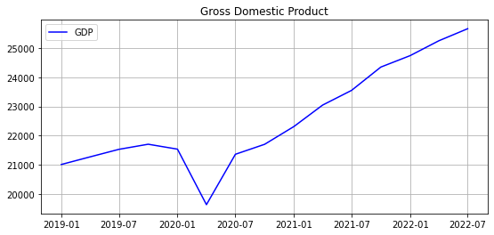

```python
gdp_path = "data/GDP.csv"
gdp_df = pd.read_csv(gdp_path)
gdp_df.head()
gdp_df['DATE'] = pd.to_datetime(gdp_df['DATE'] )
fig, ax = plt.subplots(figsize = (9,4))
ax.plot(gdp_df['DATE'], gdp_df['GDP'], color='blue', label= 'GDP')
ax.grid()
ax.legend()
plt.title("Gross Domestic Product")
plt.show()
```

## Inflation

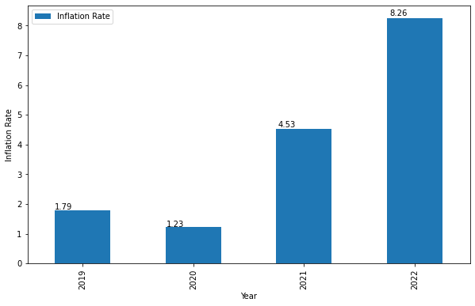

```python
data = pd.read_html('https://www.usinflationcalculator.com/inflation/historical-inflation-rates/', encoding="utf-8")
inflation_df = data[0]
inflation_df = inflation_df[(inflation_df['Year'] >= 2019)]
inflation_df["Average"] = inflation_df.iloc[:, 1:].mean(axis=1).round(2)
plot = inflation_df.plot(x="Year", y="Average", kind = "bar", figsize=(10,6), label="Inflation Rate")
plot.set_xlabel("Year")
plot.set_ylabel("Inflation Rate")
for p in plot.patches:
    plot.annotate(str(p.get_height()), (p.get_x() * 1.01, p.get_height() * 1.01))
plt.show()
```

## Federal Funds Effective Rate

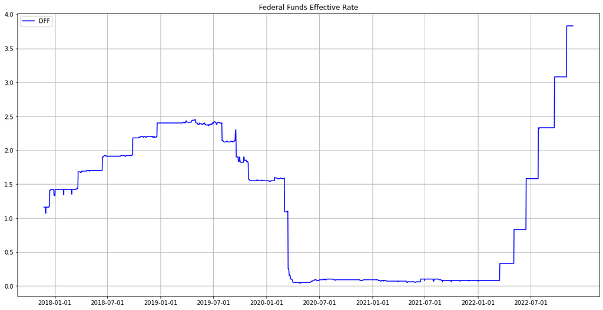

```python
ffr_path = "data/DFF.csv"
ffr_df = pd.read_csv(ffr_path)
ffr_df['DATE'] = pd.to_datetime(ffr_df['DATE'])
x_ticks = pd.date_range(start = '2018-01-01', end = '2022-7-01', freq='6MS')
fig, ax = plt.subplots(figsize = (18,9))
ax.plot(ffr_df['DATE'], ffr_df['DFF'], color='blue', label= 'DFF')
ax.grid()
ax.legend()
plt.xticks(x_ticks)
plt.title("Federal Funds Effective Rate")
plt.show()
```

#### Looking Ahead

While the first case of Covid-19 was first seen almost three years ago, the effects it has had on the world and supply chain have yet to recover. Although some industries have slowly recovered, some researchers say that the supply chain crisis will continue into 2023 or longer. Industry Leaders author Christy Gren claims “the demand for manufactured goods is expected to grow by 2.6% between now and 2024”, and although consumer spending is vital for the economy, the demands are not being met by supply. Gren also states that “due to the increasingly global supply chain shortages, manufacturers have been unable to keep up with growing demand” [(Gren)](https://www.industryleadersmagazine.com/global-supply-chain-crisis-to-continue-to-2023/). As discussed, the unfortunate inability to maintain the demand is as nearly debilitating to these companies as having the Covid-19 virus.

In addition to the lack of supplies to manufacture the demanded goods and the obstacle of Covid-19 negative effects, several other factors have caused such a rift in the supply chain. Such as, “manufacturing backlogs, high inventory levels, lack of qualified workers, economic slowdown” and more [(Gren)](https://www.industryleadersmagazine.com/global-supply-chain-crisis-to-continue-to-2023/). Gren describes the importance of each of these elements in relation to supply chain efficiency. She begins by explaining how manufacturing backlog can lead to excessive costs and unhappy customers. Specifically, unorganized or an improper amount of inventory, either too much or too little, is something important to avoid. She states, “[manufacturers] may not order enough parts leading to a surplus [or], overstocking could lead to excessive waste”, as well as excessive storage costs [(Gren)](https://www.industryleadersmagazine.com/global-supply-chain-crisis-to-continue-to-2023/). Essentially, the practice of perfecting the correct amount of product to produce is rather important, and because of all the harsher-than-ever constraints, it has put hundreds of thousands of companies into similar predicaments.

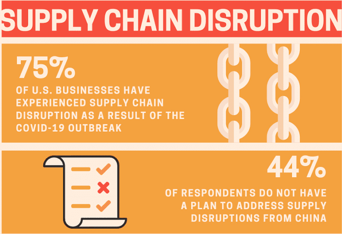

```python
Image(filename = "data/Supply-Chain-Disruption-Infgraphi-768x1024.jpg")
```

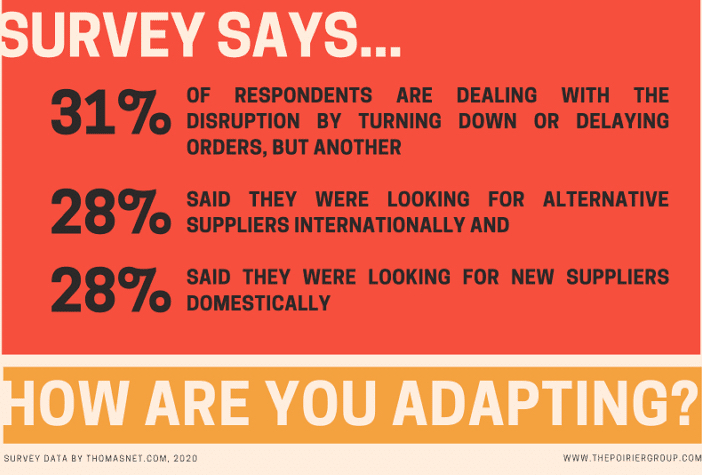

```python
Image(filename="data/Supply-Chain-Disruption-Infgraphi-768x1024 copy.jpg")
```

This graphic shows that “75% of U.S. Businesses have experienced supply chain disruption as a result of the Covid-19 outbreak, 44% of respondents do not have a plan to address supply disruptions from China” and roughly 30% of respondents are dealing with supply issues.

#### Conclusion

Considering nobody could have predicted the Covid-19 pandemics extremity, duration or even existence, the answer to how the supply chain and the world plans to fully recover is unanswered. Additionally, due to supply chain being an intricate operation in which each process is heavily reliant on the others in order to make it to the final retailer makes it all the more difficult to answer how or what it will take for the supply chain economy to be fully recovered. Due to the Fed continuously raising the benchmark rate to combat inflation, and the beneficial result not achieved, it seems that even the professionals are at a loss of efficient ideas that would decrease the two rates in order to provide a similar market to pre-Covid-19 time. This supply chain crisis caused by Covid-19 and worsetend by increasing interest rates and soviet invasions is definitely one of the worst traffic jams supply chain has ever seen.

## Works Cited

“Consumer Price Index for All Urban Consumers: Gasoline (All Types) in U.S. City Average.” FRED, 10 Nov. 2022, https://fred.stlouisfed.org/series/CUSR0000SETB01#.

Curry, David. “Amazon Statistics (2022).” Business of Apps, 11 Aug. 2022, https://www.businessofapps.com/data/amazon-statistics/.

Delgado, Mercedes, and Karen Mills. “The Supply Chain Economy and the Future of Good Jobs in America.” Harvard Business Review, 20 Jan. 2021, https://hbr.org/2018/03/the-supply-chain-economy-and-the-future-of-good-jobs-in-america.

“Domestic Auto Inventories.” FRED, 28 Oct. 2022, https://fred.stlouisfed.org/series/AUINSA. Elbein, Saul. “Here's Where US Oil and Gas Supplies Come From.” The Hill, The Hill, 12 Aug. 2022, https://thehill.com/policy/international/597389-heres-where-us-gas-supplies-come-from/#:~:text=At%20about%205%20million%20barrels%20in%202021%2C%20Russian,Canada%20%286.7%20million%29%20and%20the%20Netherlands%20%285.8%20million.%29.

## Works Cited

“Federal Funds Effective Rate.” FRED, 25 Nov. 2022, https://fred.stlouisfed.org/series/DFF. Gren, Christy. “Global Supply Chain Crisis to Continue to 2023.” Industry Leaders Magazine, 3 Feb. 2022, https://www.industryleadersmagazine.com/global-supply-chain-crisis-to-continue-to-2023/.

“Gross Domestic Product.” FRED, 27 Oct. 2022, https://fred.stlouisfed.org/series/GDP/.

Guckes, Michael. “Automotive Industry Production Data Illustrates Magnitude of Current Supply Chain Crisis.” Automotive Industry Production Data Illustrates Magnitude of Current Supply Chain Crisis | Gardner Intelligence, Gardner Intelligence, 22 Mar. 2021, https://www.gardnerintelligence.com/news/automotive-industry-production-data-illustrates-magnitude-of-current-supply-chain-crisis.

Hallman, Carly. “Average Gas Prices in the U.S. through History [Updated].” TitleMax, 9 Aug. 2022, https://www.titlemax.com/discovery-center/planes-trains-and-automobiles/average-gas-prices-through-history/#:~:text=Gas%20Prices%20in%20the%20U.S.%20Throughout%20History%20,of%20Ukraine%20begins.%20%2070%20more%20rows%20.

Hayes, Adam. “The Supply Chain: From Raw Materials to Order Fulfillment.” Investopedia, Investopedia, 8 Oct. 2022, https://www.investopedia.com/terms/s/supplychain.asp.

## Works Cited

Lee, Yen N. “Survey Finds Auto Industry Hit Hardest by Supply Chain Disruptions during Covid Pandemic.” CNBC, CNBC, 25 Aug. 2021, https://www.cnbc.com/2021/08/25/auto-industry-supply-chains-hit-hardest-during-covid-pandemic-survey.html.

O'Connell, Brian. “What Happens When the Fed Raises Interest Rates?” Forbes, Forbes Magazine, 13 Nov. 2022, https://www.forbes.com/advisor/investing/fed-raises-interest-rates/.

Palmer, Annie. “How Amazon Managed the Coronavirus Crisis and Came out Stronger.” CNBC, CNBC, 29 Sept. 2020, https://www.cnbc.com/2020/09/29/how-amazon-managed-the-coronavirus-crisis-and-came-out-stronger.html.

Sengupta, Shantanu. “Supply Chain of Coffee Business: Process, Top Brands, Future.” StartupTalky, StartupTalky, 16 Mar. 2022, https://www.startuptalky.com/supply-chain-of-coffee-market/.

“The Impact of Chip Shortage on the Auto Industry - Salvagebid.” Salvage Bid, 24 June 2022, https://www.salvagebid.com/blog/the-impact-of-chip-shortage-on-the-auto-industry/.

## Works Cited

“The Supply Chain Economy and the Future of Good Jobs in America.” Harvard Business Review, 20 Jan. 2021, https://hbr.org/2018/03/the-supply-chain-economy-and-the-future-of-good-jobs-in-america.

“Supply Chain Issues Contribution to Inflation: U.S. Bank.” Supply Chain Issues Contribution to Inflation | U.S. Bank, 11 Aug. 2022, https://www.usbank.com/investing/financial-perspectives/market-news/supply-chain-issues-contribution-to-inflation.html.

“[Infographic] Supply Chain Disruption in the Face of Covid-19.” The Poirier Group, 2 Feb. 2022, https://www.thepoiriergroup.com/infographic-supply-chain-disruption-in-the-face-of-covid-19/.